# Научная презентация

Дисциплина:Операционные системы

Абрамова У. М.

Российский университет дружбы народов, Москва, Россия

Математический институт имени Никольского, Москва, Россия

07.03.2025

# Информация

## Докладчик

- Абрамова Ульяна Михайловна
- Студент НММбд-01-24
- Российский университет дружбы народов
- 1132246782@pfur.ru
- https://github.com/Ulyana-abr

# Вводная часть

## Актуальность

- Необходимо создавать презентацию быстро
- Желательна минимизация усилий для создания презентации

## Цели и задачи

Целью данной лабораторной работы является освоение процедуры оформления отчётов с помощью легковесного языка разметки Markdown.

## Материалы и методы

- Markdown

## Содержание исследования

Далее перемещаюсь в каталог с шаблоном отчета по лабораторной работе №3 с помощью cd. Комплирую шаблон с использованием Makefile, вводя команду make (рис.2)

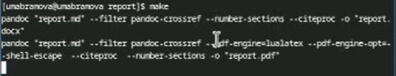

Компилирование шаблона

## Содержание исследования

Открываю сгенерированный файл report.docx, report.pdf (рис.3,4), тем самым убедившись,что все правильно сгенерировалось.

[figure not shown]

Открытие файла docx

## Содержание исследования

[figure not shown]

Открытие файла pdf

## Содержание исследования

Удаляю полученные файлы с использованием Makefile, вводя команду make clean (рис.5)

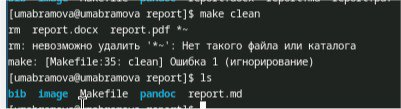

Удаление файлов

## Содержание исследования

Открываю файл report.md с помощью текстового редактора gedit (рис.6)

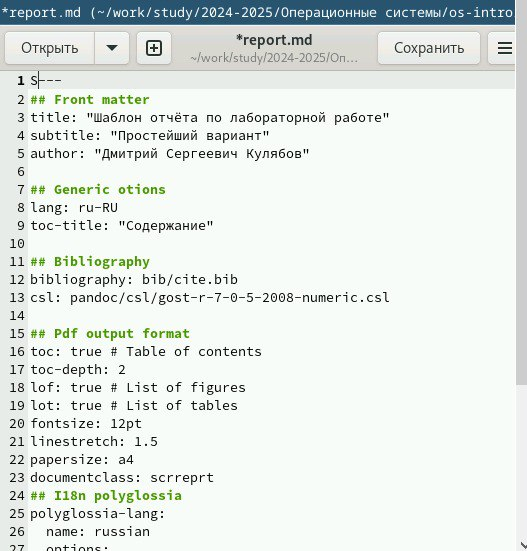

Открытие файла с помощью текстового редактора

## Содержание исследования

Начинаю заполнять отчет с помощью языка разметки Markdown в скопированном файле (рис.7)

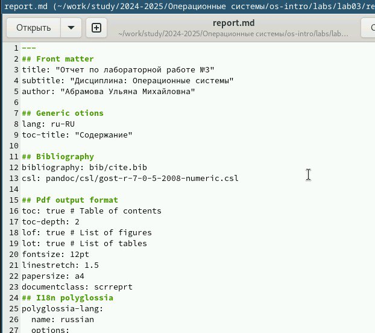

Заполнение отчета

## Содержание исследования

Компилирую файл и отправляю на GitHub (рис.8)

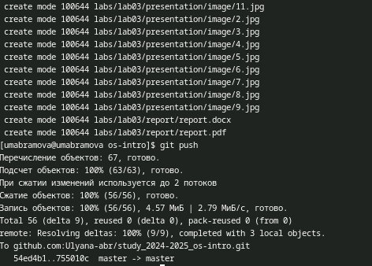

Отправка файла на сайт

## Содержание исследования

2. Выполнение заданий для самостоятельной работы Перехожу в директорию lab02/report с помощью cd, чтобы там заполнять отчёт по второй лаб.работе (рис.9)

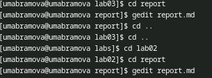

Премещение между директориями

## Содержание исследования

Файл report.md открываю с помощью текстового редактора и начинаю заполнять (рис.10)

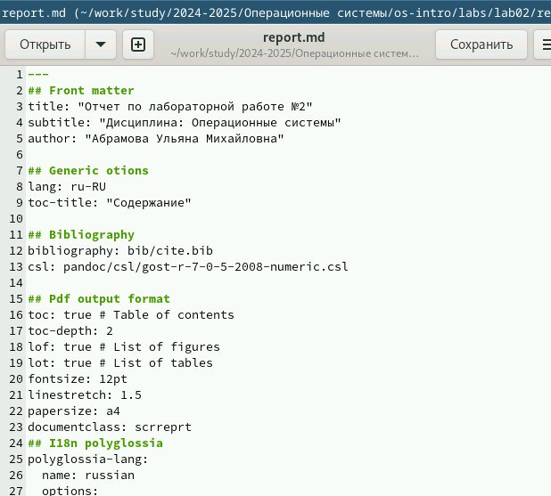

Работа над отчётом

## Содержание исследования

Компилирую файл с отчетом по лабораторной работе, добавляю изменения на GitHub с помощью команды git add и сохраняю изменения с помощью commit (рис.11)

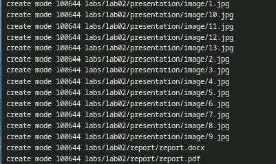

Отпрвка файлов на GitHub

## Результаты

- В результате выполнения данной лабораторной работы я освоила процедуры оформления отчетов с помощью легковесного языка разметки Markdown.

## Итоговый слайд

- Чем больше вы практикуетесь и пробуете новое, тем больше и чаще вы будете получать знаний и опыта в разных сферах.